# Essential Best Start Data

# Overview

Los Angeles County’s essential workers are the backbone of the county and essential to Best Start success. These workers tend to live and raise families in Best Start geographies, but do not earn enough income to access the resources they need to thrive. **[Most essential workers are Black, Latinx, and American Indian or Alaska Native, and Black and Latinx women disproportionately work in lower paying occupations.](https://laborcenter.berkeley.edu/front-line-essential-jobs-in-california-a-profile-of-job-and-worker-characteristics/)** Understanding the challenges essential workers face goes hand in hand with understanding racial inequities.

The challenges that COVID-19 has created disproportionately impact communities where essential workers and Black, Indigenous, Latinx and other People of Color live, including significant losses in child care, food access, income insecurity, and K-12 learning. These challenges stem from the systemic inequities that have always existed in communities of color and lower income neighborhoods. Generations of disinvestment and redlining have resulted in neighborhoods that lack robust infrastructure, creating less access to opportunities and resources. All of this contributes to a wider opportunity gap for children, especially children aged 0 to 5, in these communities.

Essential workers are supporting the county during a global pandemic. If we are serious about supporting them in return, then we must examine the systemic failures that drive the conditions essential workers and their families face, and confront the racial disparities that exist. If we want to create a post-pandemic world that is more equitable than the one before, then we must shift our mental models and reimagine how we think about essential workers to drive transformative and sustainable change for families.

**The map below shows that essential workers predominantly live in and around Best Start geographies.** Thus, supporting families in Best Start geographies in turn supports essential workers and their families. Essential workers include health practitioners, food service workers, and early learning and care providers. The darker red areas on the map represent higher numbers of essential workers relative to the lighter red portions of the map. Most of the dark red areas on the map are within Best Start geography boundaries (outlined in black).

**Why this matters:** Supporting families in Best Start geographies in turn supports essential workers and their families. Best start geographies are comprised of predominantly Black and Latinx families, many with young children age 0 to 5, and Black and Latinx women disproportionately represent lower paid essential workers.

[interactive chart not shown]

Source: 2019 ACS 5-Year Estimates

## Methodology

First 5 LA Program Officers and Regional Network Grantees were interviewed in Spring of 2020 to incorporate their perspectives from working directly with community members in the Best Start geographies into the design and content of this report. Data that was identified in the interviews and the Best Start Change Agendas are analyzed and visualized for Program Officers and Regional Network Grantees to use in their work.

The policy opportunities introduced here identify what a better post-pandemic landscape looks like, while also not losing site of the immediate needs of families and service providers. Specifically, the policy opportunities in this report focus on closing opportunity gaps for Best Start geographies through:

1. Systems change
2. Infrastructure to support children and families
3. Direct services and technical assistance

Policy opportunities and findings also include relationships to First 5 LA’s Strategic Framework and offer considerations for state and local leadership to impact the greatest needs for young children and families.

## Key Findings

- **[Financial insecurity](https://jzhang514.github.io/f5la/Real-Cost-Measure.html)** and the **[digital divide](https://jzhang514.github.io/f5la/Child-Care.html#Internet_Access)** are the two top themes that came out across all five regions from both Program Officers and Regional Network Grantees.
- In addition to lifting themes that resonate with what family needs are, several First 5 LA Program Officers cited the importance of understanding the **[nonprofit landscape](https://jzhang514.github.io/f5la/Appendix)** of their best start geographies to support nonprofit capacity and understand who key players are and form partnerships.

[output not shown]

# Who are the Essential Workers Living in Best Start Geographies

Understanding who lives in Best Start geographies is foundational to addressing the systemic inequities Best Start families and children face. The Best Start geographies reflect communities with a higher Latinx and Black population, as well as a higher age 0 to 5 population.

As First 5 LA reaffirms its commitment to anti-racism and combating anti-blackness, it is imperative that the specific needs and experiences of Black families in the Best Start Geographies are thoroughly examined. How anti-Blackness can be applied to Best Start work can be thought of in two ways: 1) Paying attention to racial disparities or unconscious biases that exist within systems as it relates to Best Start work, and 2) Imagining new priorities and initiatives through direct and intentional engagement with black community members and black-led community partners.

[Click here to view the African American data pull out](https://jzhang514.github.io/f5la/African-American-Data-Pullout) [Click here to explore the demographics of the Best Start Geographies](https://jzhang514.github.io/f5la/Demographics.html)

# What does it really cost to support essential workers

**[Promesa Boyle Heights (PBH)](https://www.promesaboyleheights.org/)** is a resident-led place-based organization working with residents in Boyle Heights and East LA on issues of immigration, healthy environments, early learning, and wellness and mental health supports. During the pandemic and witnessing the critical employment needs of the community, PBH repurposed existing grant funds to expand their stipend resident leader program to bring on 22 part-time positions to continue and deepen PBH’s community-led work.

The work that PBH is doing with resident leaders aligns with a consistent theme that came up in interviews with Program Officers and Regional Network Grantees: financial security. Financial security, especially in conjunction with rent burden, was raised as the highest priority for families across all five Best Start regions. Job loss and increased uncertainty during the pandemic puts families in impossible positions as they continue to work. Rent burden, the cost of food, and increased reliance on remote technologies are just some examples of the needs that add financial strain to families.

To begin understanding the way in which financial security is connected to every essential aspect of a family’s life, this project uses the **[Real Cost Measure](https://www.unitedwaysca.org/realcost)** to illustrate what it really costs for a family with two children (one age 0-5 and one school-aged) to meet their essential needs in Los Angeles County. The Real Cost Measure takes into consideration the cost of living in Los Angeles County and measures the minimum budget for the necessary domains of life: Child Care, Food, Health Care, Housing, Transportation, Taxes and Miscellaneous items.

[Click here to explore Real Cost Measure Data for the Best Start Geographies](https://jzhang514.github.io/f5la/Real-Cost-Measure.html)

# Findings and Policy Opportunities

This section of the report dives deeper into each of the basic need areas captured by the Real Cost Measure. All of them align with priorities listed on Best Start Change Agendas and themes lifted up during conversations with First 5 LA Program Officers and Regional Network Grantees. This alignment highlights the overlap that exists between food, housing, transportation, child care and health care, and the ways in which broader systems change and infrastructure to support children and families are needed. The creation or enhancements of specific programs in child care or health care alone are insufficient to close the opportunity gaps essential workers face. Supporting essential workers requires policies that address immediate family needs and long-term systemic change. Sufficient support must be given to family first responders, including direct service agencies and nonprofit organizations. At the same time, investing in long-term infrastructure and systemic reform is critical to alleviating preexisting inequities that are worsening during the pandemic.

The policy opportunities introduced here focus on three areas:

1. Systems change
2. Creation of infrastructure to support children and families
3. Direct services and technical assistance to close the opportunity gap for families of essential workers in the Best Start geographies

Many policy opportunities cited here stem from community collective impact equity initiatives like Bold Vision and existing regional housing, health, transportation, and economic justice campaigns such as Healthy LA, Alliance for Community Transit, and conversations with child care providers and dual language learner partners.

## Child care

[figure not shown]

Supporting child care needs for families is connected to supporting child care providers. Providers are predominately immigrant women of color, and they are the ones who are watching the children of other essential workers. During the pandemic, providers like **[Sue Carrera, a licensed child care provider who has worked in Inglewood for 30 years](https://www.advancementprojectca.org/blog/serving-infants-toddlers-and-school-aged-children-during-covid-19)**, have had to adjust to constantly evolving safety guidelines, in some cases accepting older children into child care, all while managing their own personal safety. All of this creates immense emotional and financial burdens on providers, who now have higher costs to stay open without the financial and technical support to match. Policies that provide more immediate financial support and tools to providers are desperately needed to ensure that they are being set up to succeed for the monumental task they have.

### Policy Opportunities

Supporting child care needs for families is connected to supporting child care providers. Providers, who are essential workers, are predominately immigrant women of color. [They are the ones who are watching children while their parents continue to work in their own essential occupations.](https://www.advancementprojectca.org/blog/the-necessity-of-staying-open-during-Covid-19) During the pandemic, providers have had to adjust to Covid-19 safety guidelines, meet their financial needs in increasingly difficult circumstances, provide a safe space for children of essential workers, all while managing their own personal safety. Policies that provide more immediate financial support and tools to providers is desperately needed to ensure that they are being set up to succeed for the monumental task they have.

[Click here to explore data and policy opportunities on child care providers and access early child care education](https://jzhang514.github.io/f5la/Child-Care.html)

## Food

[figure not shown]

Systemic inequities in the food system created the immediate and urgent prioritization of food access during the pandemic. Local food systems are not currently set up to distribute healthy and affordable food equitably across all local communities. The 2020 LA Food Policy Council (LAFPC) Dashboard combines powerful numbers with personal testimonials to illustrate the landscape of local food systems in Los Angeles.

At the local level, First 5 LA Program Officers and Regional Network Grantees quickly ascertained the need for food access among families through phone outreach and engagement with families in Best Start geographies. First 5 LA recognized the need for families to be connected to food banks and other resources that were being made available but not easily accessible. This identified need prompted the partnership between First 5 LA and Metro LA.

### Policy Opportunities

The failures of the current food landscape and the resulting inaccessibility to food are painfully clear during the pandemic. Serious investment is needed to reshape food access and empower communities to be able to create their own sources for healthy and affordable food, through green spaces and local businesses. The current reliance on K-12 schools for meals has long been an insufficient and inequitable system for food access. Funding must be directed to new sources of healthy food that are community-owned and empowering to communities of color.

[Click here to explore data and policy opportunities on food access](https://jzhang514.github.io/f5la/Food.html)

## Health care

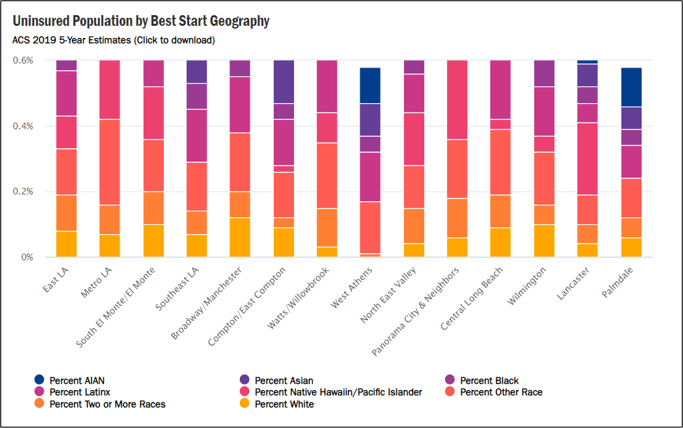

### Policy Opportunities

Covid-19 has heightened the need for health insurance and access to health care facilities. That is why the conversation surrounding the digital divide and access to technology must also include telehealth and the ability for families to receive health care services remotely and safely. However, it is crucial to think about health holistically. A child’s safety is an intrinsic aspect of her health. Ensuring that children are in safe home situations is more crucial than ever given the increased isolation children are facing in lockdown. Ultimately, investing in a comprehensive continuum of care is needed to ensure that families and children are safe and have all of their health needs met in a preventative and timely manner.

[Click here to explore more health care data and policy opportunities](https://jzhang514.github.io/f5la/Health-Care.html)

## Housing

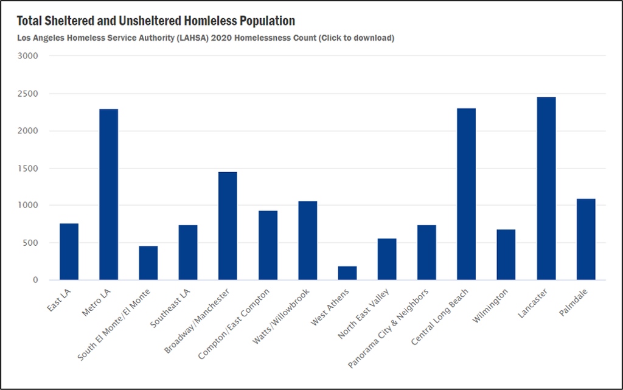

### Policy Opportunities

Housing is arguably the number one issue that concerns families in Los Angeles County, so it is unsurprising when talking about family priorities in the Best Start Geographies that housing came up consistently. Increasing job insecurity and financial strains from the pandemic have made the high rent burden feel even more painful for families. Policies must quickly be enacted to cancel rent and evictions and ensure housing security. In addition to improving housing security, investments need to be directed to unused spaces to repurpose them for housing, health and child care needs.

[Click here to explore more housing data and policy opportunities](https://jzhang514.github.io/f5la/Housing.html)

## Transportation

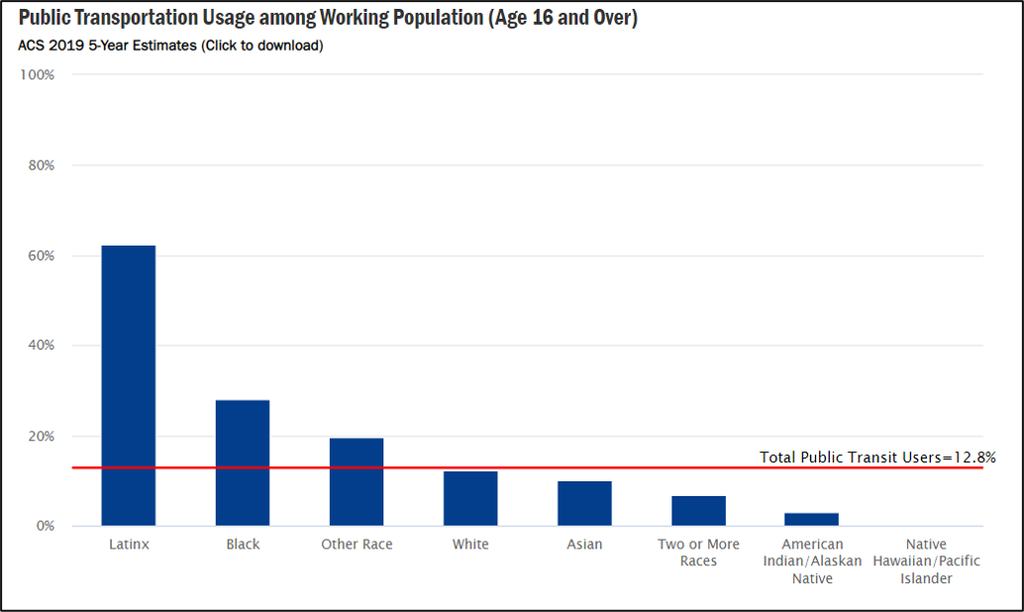

### Policy Opportunities

Public transportation is inherent to access, whether it is to grocery stores for food or child care centers for children. It is a core tenant of a community’s built environment and requires robust infrastructure and investment to ensure that it connects families to essential services. In light of the pandemic, many families are feeling the consequences of poor public transportation infrastructure as inaccessibility worsens. Safety is also a growing concern as crowded buses further the spread of disease. A stronger public transportation infrastructure that includes more bus options and flexible transit improves the safety of both riders and bus drivers.

[Click here to explore more transportation data and policy opportunities](https://jzhang514.github.io/f5la/Transportation.html)

## Additional Priority Areas

### Systems Change

- **Utilize a targeted approach to prioritize supports for highest-need communities, where a large segment of essential workers resides, using an Equity Index.** Using a community-built Equity Index, allocate dollars more equitably across child-focused systems. A research-based ranking of communities facing the greatest challenges would enable leaders to prioritize and repair under-investments of our highest-need communities, including in Best Start geographies, at a time when our families need more support than ever. **F5LA Result: Family Resources**
- **Build capacity for case management in child-focused systems to be welcoming, family-centered, and aligned** so that families of color and essential workers can easily access critical information, resources, and opportunities. **F5LA Result: Early Intervention**
  - Develop uniform eligibility and single application process for child-focused programs (e.g., CalFresh, Medi-Cal, Supplemental Nutrition Program for Women, Infants, and Children, California Earned Income Tax Credit, Early Learning and Care programs). Integrating applications and building safe data sharing practices across programs can address the challenges families face using multiple and lengthy eligibility verification and enrollment processes and address the delay in services, families inaccurately losing eligibility and additional administrative costs, much of which has been exacerbated under Covid-19.
  - Ensure no family falls through the cracks in obtaining information and resources for their children, starting from prenatal visits. Facilitate data sharing between hospitals, regional offices, county, and city levels with ongoing touchpoints to support families. Data protection and safety for undocumented families must be the priority in developing this aligned data system. **F5LA Result: Early Intervention** **F5LA Result: Family Resources**
  - Provide implicit bias and culturally and linguistically responsive training for all staff/case managers working with young children and families of essential workers. Anti-racism and anti-bias support and training should be provided to case managers, staff, and early learning professionals across programs so that no family falls through the cracks due to lack of cultural sensitivity or complications in navigating different bureaus and paperwork.

### Infrastrcture to Support Children and Families

- **Partner with districts to provide every student and family with access to devices and internet (e.g., laptops and hotspots).** Children of color and from low-income communities are likely to suffer from widening opportunity gaps without access to schools. During the past months, as school districts and organizations moved quickly to support families, technology and internet companies scrambled to offer “free” internet and Wi-Fi services for students and families in low-income communities. There is need to grow and monitor these efforts to ensure they meet the needs of students facing the greatest and most urgent barriers to technology access and distance learning. Digital justice and digital divide concerns were raised across all Best Start geographies. One third of LAUSD students in Region 1 are not able to access learning due to lack of digital and technology access. **F5LA Result: Family Resources**
- **Create Whole Family Wellness Hubs, such as Magnolia Place Family Center, in highest-need communities, as determined by an Equity Index.** Whole Family Wellness Hubs provide wraparound services (including prenatal and child care social services, mental and behavioral health supports) that are linguistically and culturally responsive to children and families through structured partnerships between community entities and service providers that are tailored to the unique contours of each community, as determined by a community assessment. **F5LA Result: Family Resources** **F5LA Result: Early Intervention**
- **Develop an Early Childhood Integrated Data system that includes critical community-based racial equity data** such as race, home language, family needs, and preschool suspensions/expulsions to assist stakeholders to understand the needs of children and families and strategize supports for quality improvement with nuanced data about program access, participation, and child outcomes. **F5LA Result: Early Learning**
- **Engage families to share evolving circumstances and needs.** Ongoing engagement with families would provide clear channels that connect the evolving needs of essential workers with policy and decision-makers (such as the [Covid-19 Parent Survey](https://rrnetwork.org/research/Covid-19-parent-survey) or Region 1’s Community Survey). Ensure parents and families are compensated as they share their expertise and recommendations. **F5LA Result: Family Resources**
- **Extend family fee waivers or prioritize funding support to remove family fees for all state-subsidized early learning and care programs.** This would support the many families of essential workers that are unable to pay family fees for childcare, and it would also protect child care providers from absorbing the costs of fees which place them in incredibly vulnerable financial positions to keep their homes/centers open. **F5LA Result: Family Resources**
- **Provide supports for direct engagement with Black and American Indian and Alaska Native families and individuals within the Best Start Network.** Ongoing direct engagement with Black, American Indian, and Alaska Native families across all the Network would enable grantees to identify specific needs and supports essential to these communities. **F5LA Result: Family Resources**

### Specific Support of Programs

- **Deliver family strengthening supports, such as home visiting and community health worker/promotora programs.** Community-centered, culturally, and linguistically competent, asset-based family strengthening programs, such as home visiting through calls, video chat, and text check-ins, are important as families shelter in place due to the pandemic. These programs connect families with community-based doulas, nurses, social workers, and other trained professionals that provide health and early education support. **F5LA Result: Family Resources**
- **Create a Universal Basic Income Program.** Ensure a guaranteed income for Best Start families. Create pilot projects like what has been done in Stockton and Minneapolis. **F5LA Result: Family Resources**

# Promising Practices

Prior to the pandemic, many Program Officers and Regional Network Grantees were engaged in systems-level change and strategic planning with community members. This work focused on capacity building and examining systemic policies that impacted families in the Best Start geographies. Immediate food and supply shortages caused by the pandemic forced partners to shift to direct service provision and coordination. Program Officers and Regional Network Grantees across all five regions quickly mobilized virtual methods of communication and directly contacted families to assess needs. Taking advantage of flexible funding streams from First 5 LA, Regional Network Grantees and Program Officers found creative solutions to support families and challenge the role of existing systems to better serve community needs. These promising practices are learning opportunities for First 5 LA moving forward. The long-term impacts of Covid-19 provide an opportunity for First 5 LA to reimagine the role Program Officers and Regional Network Grantees can play in creating a new normal that holistically supports programs, infrastructure, and systems that close the opportunity gap for families and children.

## Region 1: Metro and Food Delivery

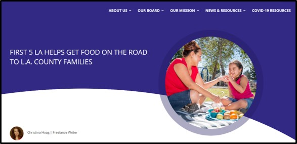

Food insecurity immediately emerged as a pressing priority for families at the start of the pandemic. Through efficiently deployed outreach calls and surveys, Program Officers and Regional Network Grantees identified exactly what families needed. The problem with food insecurity was not just a lack of food options, but a lack of information and access. At the beginning of the pandemic, many local organizations launched food banks, but families were unable to access them. First 5 LA connected with LA Metro to create a program that delivers food and essentials directly to families. The program was so successful that it is now in the process of being expanded across all five regions.

## Region 2: Free Wifi through Housing Project

Region 2 conducted surveys to understand the needs of the families and identified a digital divide that made accessing critical information and resources more difficult during the pandemic. One of the community partners is now working to provide free potable wifi to families using an empty housing project.

## Region 3: Cedar Sinai and Food Delivery

Program Officers and Regional Network Grantees in Region 3 are have partnered with Cedar Sinai to serve as a food distribution center for families and increase food access.

## Region 4: Helping Families Obtain Resources and Public Assistance

Many undocumented families have been hesitant to access Covid-19 testing or public relief programs for fear of deportation. In response partners are connecting families to resources, crowdsourcing funding for immediate economic relief, and educating families on resources and their rights.

## Region 5: Preschool Without Walls (PWW)

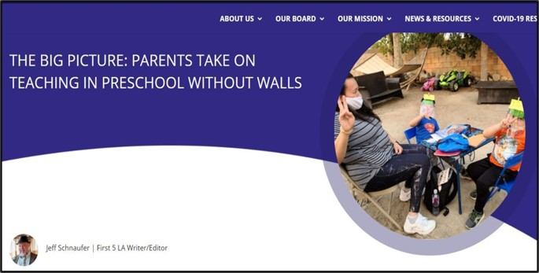

The pandemic has undoubtedly created challenges for families, but it also demonstrates their ongoing resilience. As schools and childcare centers closed or transitioned online classes, many parents knew that their children still needed to continue their learning and engagement. Preschool Without Walls PWW) is one example of how that need translated into a creative and responsive solution. PWW hosts free weekly education classes for young children in public parks and community wellness centers in Lancaster and Palmdale. Another unique aspect of PWW: Parent volunteers teach the classes and are actively involved in classes. Free outdoor childcare responds to the immediate needs of families during a pandemic, but it also tackles the systemic issues that extend beyond the pandemic by providing parental support in early childhood education and providing alternatives to the status quo of lengthy waitlists and unaffordable early learning programs.

# Appendix

[Click here for the full Appendix, which includes raw data tables and crosswalks for downloading](https://jzhang514.github.io/f5la/Appendix)

# Index of Indicators

| Indicator | Data Source | Year |
| --- | --- | --- |
| Essential Workers | American Community Survey (ACS) Census Bureau | 2019 |
| Children Age 0 to 5 | American Community Survey (ACS) Census Bureau | 2019 |
| Race and Ethnicity | American Community Survey (ACS) Census Bureau | 2019 |
| Undocumented Population | USC CSII analysis of 2018 5-year American Community Survey (ACS) microdata from IPUMS USA | 2018 |
| Median Household Income | American Community Survey (ACS) Census Bureau | 2019 |
| Best Start Regions Crosswalk | First 5 LA | 2021 |
| Real Cost Measure Annual Budget | United Ways of California | 2019 |
| Households Below the Real Cost Measure by Best Start Geography | United Ways of California | 2019 |
| Households Below the Real Cost Measure by Race | United Ways of California | 2019 |
| Child Care Workers in Best Start Geographies | Center for Economic and Policy Research Analysis of American Community Survey (ACS) Data | 2018 |

[output cut: 13 more lines]

# Frequently Asked Questions (FAQs)

**Question: What year is the data from?**

This webpage uses data from a variety of different sources. All of the data visuals have data captions listing the source and year. Consolidated information on the data sources and years of every indicator on this webpage can be found in the Index of Indicators section.

**Question: Can I download the data visualizations?**

Yes. Each data visualization has three horizontal lines on the top right corner that you can click to download the image. Note that the interactive pop up messages you see when you hover over the graphs will not be part of the image download.

**Question: How are the Best Start Geographies defined?**

For the different geography levels present on this webpage (i.e. Census Tract, PUMA, Zip Code), a crosswalk was made to map the geographies to the Best Start Geography. For example, the percentage of the population age 0 to 5 in each of the Best Start Geographies is calculated at the Census Tract level. A crosswalk was created to determine the Census Tracts that are contained within each of the Best Start geographies. Crosswalk tables that map the PUMAS, Census Tracts and Zip Codes that are contained in each of the Best Start geographies can be downloaded [here](https://jzhang514.github.io/f5la/Appendix)

# Acknowledgements

[Advancement Project California](https://www.advancementprojectca.org/) partnered with First 5 LA to engage with internal stakeholders and community partners working in the Best Start geographies The Advancement Project California thanks every Regional Network Grantee and Program Officer who was interviewed. The insights shared guided the direction of this deliverable and ensured that it remained connected to the families residing in the Best Start geographies. Sincerest thank you to United Way, California Food Policy Advocates, the Los Angeles Food Policy Council, and the Child Care Resource Center for lending your expertise and insight on data indicators.

[figure not shown]